# Análise de Dados de Transcriptômica Espacial

Análises Downstream: deconvolução, comunicação celular e segmentação celular

Flávio Gabriel Carazza-Kessler

SysbioLab | UFPR

# Abertura

## Roteiro da aula

| Bloco | Etapas |
| --- | --- |
| RCTD | carregar ‘stxBrain’, preparar referência single-cell, construir objeto lido pelo RCTD, executar deconvolução, anotar spots no dado espacial |
| CellChat | carregar ‘stxBrain’, preparar objeto CellChat, definir banco de dados de ligantes-receptores, inferir comunicação célula-célula, imputar dados à nível de spot, visualizar com pacote PathwaySpace |
| Segmentação celular | carregar objeto preparado, inspecionar geometrias, representação das células como polígonos, visualização |

## Encadeamento analítico

**Composição**

Quais tipos celulares contribuem para cada spot?

*RCTD*

**Comunicação**

Quais pares ligante-receptor conectam regiões vizinhas?

*CellChat + PathwaySpace*

**Segmentação celular**

Como limites celulares mudam a representação espacial?

*Visium HD + geometrias sf*

# Deconvolução com RCTD

Vinheta de referência: **RCTD — deconvolução do stxBrain**

## Por que *deconvoluir* spots

- Um spot Visium pode conter RNA de várias células.
- A expressão observada mistura perfis de tipos celulares diferentes.
- Uma referência single-cell anotada fornece os perfis de expressão esperados.
- O RCTD estima a contribuição dos tipos celulares para cada spot (Cable et al. 2022).

> Em anotação/deconvolução de tipos celulares com uso de uma REFERÊNCIA será sempre “enviesada” por ela. Referência boa, anotação boa.

## Modelo conceitual do RCTD

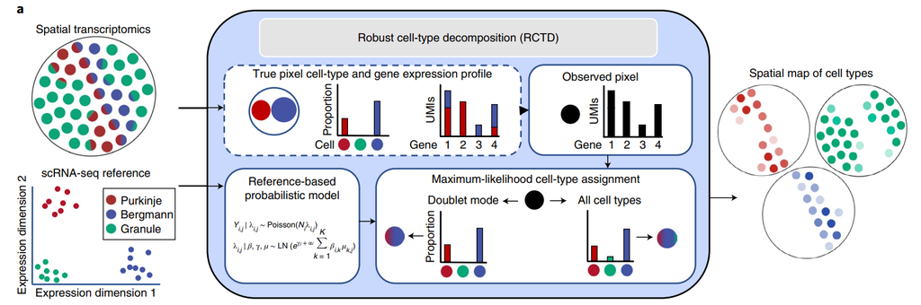

O RCTD combina uma referência single-cell, contagens espaciais e um modelo probabilístico para mapear tipos celulares. Fonte: Cable et al. (2022).

## Entradas e saída

| Componente | Objeto | Informação usada |
| --- | --- | --- |
| amostra espacial | stxBrain anterior1 | contagens brutas e coordenadas |
| referência | córtex de camundongo do Allen Institute (Tasic et al. 2016) | contagens brutas e tipo celular |
| resultado | objeto RCTD | classe do spot, tipos e pesos |

As duas matrizes precisam usar identificadores gênicos compatíveis e contagens inteiras.

[figure not shown]

stxBrain anterior1

[figure not shown]

Referência single-cell: córtex de camumdongo.

## Modos de ajuste

**doublet**: atribui no máximo dois tipos celulares por spot.

**multi**: permite até o limite configurado em MAX_MULTI_TYPES.

**full**: não impõe um número fixo de tipos.

O curso usa o modo *doublet* para manter o custo computacional controlado. A restrição descreve o modelo, não a quantidade real de células no spot.

## Custo computacional

- A referência do Allen Institute ocupa cerca de 1 GB em disco e aproximadamente 3 GB em memória.
- A execução validada do RCTD levou 14,22 minutos em um servidor com 30 núcleos e 160Gb de RAM.
- No Windows, o fluxo original permite utilizar apenas um núcleo.

## Conferir o ambiente

```r
pacotes_rctd <- c(
  "Seurat", "SeuratObject", "SeuratData", "Matrix", "ggplot2", "spacexr"
)

pacotes_rctd_ausentes <- pacotes_rctd[
  !vapply(pacotes_rctd, requireNamespace, logical(1), quietly = TRUE)
]

if (length(pacotes_rctd_ausentes) > 0) {
  stop(
    "Execute primeiro Configuracao_do_ambiente_RStudio.Rmd. ",
    "Pacotes ausentes: ",
    paste(pacotes_rctd_ausentes, collapse = ", ")
  )
}
```

## Diretórios e pacotes

```r
diretorio_vinhetas <- getwd()

diretorio_curso <- dirname(diretorio_vinhetas)
diretorio_dados <- file.path(diretorio_curso, "data")
diretorio_imagens <- file.path(diretorio_curso, "imagens")
diretorio_resultados <- file.path(diretorio_curso, "resultados")

dir.create(diretorio_dados, showWarnings = FALSE, recursive = TRUE)
dir.create(diretorio_imagens, showWarnings = FALSE, recursive = TRUE)
dir.create(diretorio_resultados, showWarnings = FALSE, recursive = TRUE)
```

```r
library("Seurat")
library("SeuratData")
library("Matrix")
library("ggplot2")
library("spacexr")

options(stringsAsFactors = FALSE)
```

## Carregar a amostra espacial

```r
if (!requireNamespace("stxBrain.SeuratData", quietly = TRUE)) {
  stop(
    "O conjunto stxBrain não está instalado.\nExecute primeiro a vinheta ",
    "Configuracao_do_ambiente_RStudio.Rmd: \n",
    "https://flaviogckessler.github.io/Curso_ST/vinhetas/Configuracao_do_ambiente_RStudio.html"
  )
}

message("O conjunto stxBrain já foi instalado.")

stxbrain <- SeuratData::LoadData("stxBrain", type = "anterior1")
stxbrain
```

## Contagens espaciais brutas

```r
contagens_espaciais <- SeuratObject::LayerData(
  object = stxbrain,
  assay = "Spatial",
  layer = "counts"
)

print(paste("Número de spots:",dim(contagens_espaciais)[2]))
print(paste("Número de genes:",dim(contagens_espaciais)[1]))

contagens_espaciais[
   seq_len(min(5L, nrow(contagens_espaciais))),
   seq_len(min(5L, ncol(contagens_espaciais))),
   drop = FALSE]
```

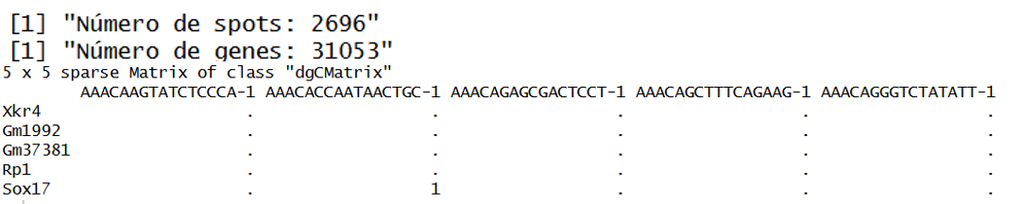

Contagens inteiras da camada Spatial.

## Profundidade por spot

```r
summary(Matrix::colSums(contagens_espaciais))
```

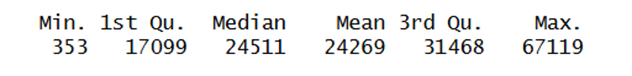

Resumo do total de transcritos por spot.

## Coordenadas dos spots

```r
nome_imagem <- SeuratObject::Images(stxbrain)[1]
coordenadas_espaciais <- SeuratObject::GetTissueCoordinates(
  object = stxbrain,
  image = nome_imagem,
  scale = NULL
)

coordenadas_espaciais <- as.data.frame(
  coordenadas_espaciais[, c("x", "y"), drop = FALSE]
)
coordenadas_espaciais <- coordenadas_espaciais[
  colnames(contagens_espaciais), , drop = FALSE
]

head(coordenadas_espaciais)
```

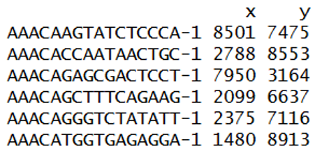

Coordenadas alinhadas às colunas da matriz de contagens.

## Referência single-cell

```r
arquivo_referencia <- file.path(diretorio_dados, "allen_cortex.rds")

if (!file.exists(arquivo_referencia)) {
  stop(
    "A referência single-cell não foi encontrada em: ",
    arquivo_referencia,
    "\nBaixe o arquivo como descrito acima ou copie o arquivo fornecido pelo instrutor para data/."
  )
}

referencia_allen <- readRDS(arquivo_referencia)
metadados_referencia <- referencia_allen[[]]

contagens_referencia <- SeuratObject::LayerData(
  object = referencia_allen,
  assay = "RNA",
  layer = "counts"
)
head(contagens_referencia[,1:5])
```

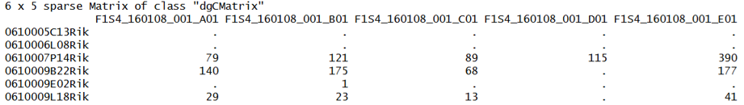

Matriz de contagens da referência.

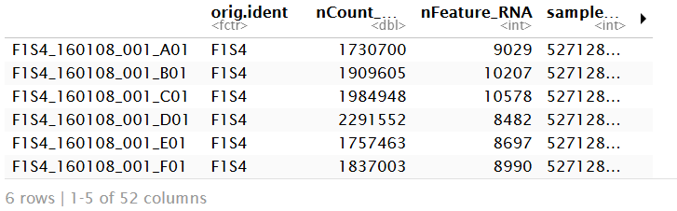

Metadados da referência.

## Rótulos e tipos raros

```r
metadados_referencia <- metadados_referencia[
  colnames(contagens_referencia), , drop = FALSE
]

tipos_celulares_referencia <- as.character(
  metadados_referencia$subclass
)
tipos_celulares_referencia <- gsub(
  "/", "-", tipos_celulares_referencia, fixed = TRUE
)

celulas_validas <- !is.na(tipos_celulares_referencia) &
  nzchar(tipos_celulares_referencia)

tamanhos_tipos <- table(tipos_celulares_referencia[celulas_validas])
tipos_elegiveis <- names(tamanhos_tipos[tamanhos_tipos >= 25])
celulas_validas <- celulas_validas &
  tipos_celulares_referencia %in% tipos_elegiveis
```

[figure not shown]

## Filtrar a matriz da referência

```r
contagens_referencia <- contagens_referencia[
  , celulas_validas, drop = FALSE
]
tipos_celulares_referencia <- droplevels(
  factor(tipos_celulares_referencia[celulas_validas])
)

print(paste("N° de células de referência: ",ncol(contagens_referencia)))
print("Células de referência:")
levels(tipos_celulares_referencia)
```

O filtro padrão mantém somente tipos celulares representados por pelo menos 25 células.

## Genes compartilhados

```r
genes_comuns <- intersect(
  rownames(contagens_espaciais),
  rownames(contagens_referencia)
)

resumo_genes <- data.frame(
  fonte = c("amostra espacial", "referência single-cell", "interseção"),
  numero_de_genes = c(
    nrow(contagens_espaciais),
    nrow(contagens_referencia),
    length(genes_comuns)
  )
)
resumo_genes

contagens_espaciais <- contagens_espaciais[
  genes_comuns, , drop = FALSE
]
contagens_referencia <- contagens_referencia[
  genes_comuns, , drop = FALSE
]
```

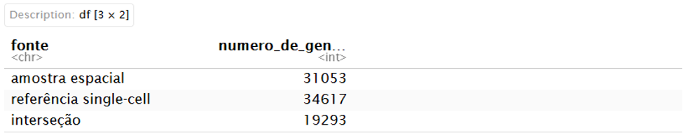

Número de genes na amostra, na referência e na interseção.

## Objetos de entrada do spacexr

```r
names(tipos_celulares_referencia) <- colnames(contagens_referencia)

referencia_rctd <- spacexr::Reference(
  contagens_referencia,
  tipos_celulares_referencia,
  Matrix::colSums(contagens_referencia)
)

consulta_rctd <- spacexr::SpatialRNA(
  as.data.frame(coordenadas_espaciais),
  contagens_espaciais,
  Matrix::colSums(contagens_espaciais)
)

data.frame(objeto = c("referencia_rctd", "consulta_rctd"),
  genes = c(nrow(referencia_rctd@counts),nrow(consulta_rctd@counts)),
  unidades = c(ncol(referencia_rctd@counts),ncol(consulta_rctd@counts)),
  tipo_de_unidade = c("células", "spots"))
```

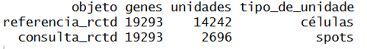

Dimensões dos objetos de referência e consulta.

## Criar e executar o RCTD

```r
set.seed(20260904)

numero_nucleos <- 1

RCTD <- spacexr::create.RCTD(
  consulta_rctd,
  referencia_rctd,
  max_cores = numero_nucleos
)

inicio_rctd <- Sys.time()

RCTD <- spacexr::run.RCTD(
  RCTD,
  doublet_mode = "doublet"
)

fim_rctd <- Sys.time()
tempo_rctd <- fim_rctd - inicio_rctd
tempo_rctd
```

> CUIDADO: Este bloco é o mais pesado da aula, não rode na sua máquina enquanto você não garantir a estrutura necessária.

## Inspecionar os resultados

```r
resultado_spots <- RCTD@results$results_df
pesos_doublet <- as.data.frame(RCTD@results$weights_doublet)
colnames(pesos_doublet) <- c("peso_primeiro_tipo", "peso_segundo_tipo")

resumo_spots_rctd <- cbind(resultado_spots, pesos_doublet)

head(resumo_spots_rctd)
table(resumo_spots_rctd$spot_class)
```

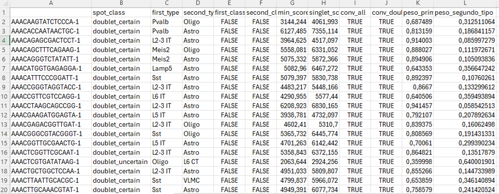

Classificação, tipos celulares e pesos estimados por spot.

## Composição das classes

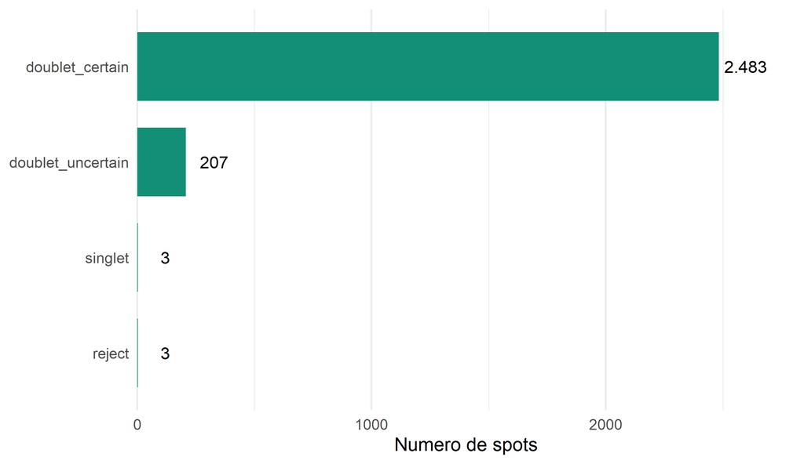

```r
ggplot(
  tab_classe_rctd,
  aes(x = reorder(classe, spots), y = spots)
) +
  geom_col(fill = "#148F77", width = 0.72) +
  geom_text(
    aes(label = format(spots, big.mark = ".")),
    hjust = -0.12,
    size = 4.8
  ) +
  coord_flip(clip = "off") +
  scale_y_continuous(expand = expansion(mult = c(0, 0.13))) +
  labs(x = NULL, y = "Numero de spots") +
  theme(panel.grid.major.y = element_blank())
```

## Acrescentar as anotações ao Seurat

```r
stxbrain <- SeuratObject::AddMetaData(
  object = stxbrain,
  metadata = resumo_spots_rctd
)
```

As linhas de resumo são alinhadas aos spots pelos códigos de barras.

## Classificação espacial

```r
p_classes <- Seurat::SpatialDimPlot(
  object = stxbrain,
  images = nome_imagem,
  group.by = "spot_class",
  pt.size.factor = 1.6,
  crop = TRUE
) +
  labs(title = "Classificação dos spots pelo RCTD")

p_classes
```

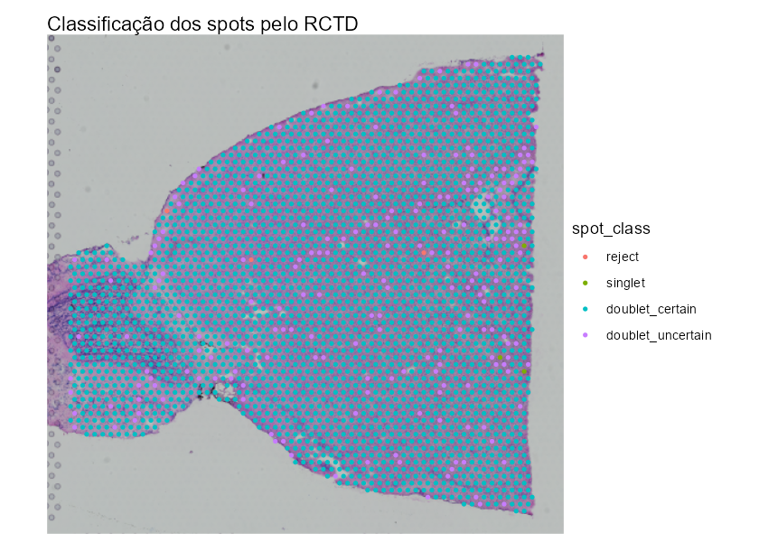

Classificação dos spots pelo RCTD.

## Primeiro e segundo tipos celulares

```r
p1 <- Seurat::SpatialDimPlot(
  object = stxbrain,
  images = nome_imagem,
  group.by = "first_type",
  pt.size.factor = 1.6,
  crop = TRUE
) +
  labs(title = "Primeiro tipo celular")

p2 <- Seurat::SpatialDimPlot(
  object = stxbrain,
  images = nome_imagem,
  group.by = "second_type",
  pt.size.factor = 1.6,
  crop = TRUE
) +
  labs(title = "Segundo tipo celular")

p_tipos <- p1 + p2
p_tipos
```

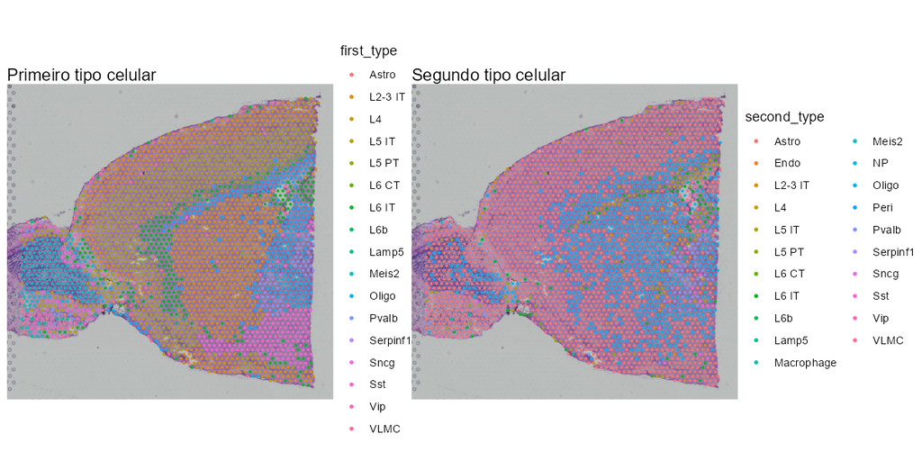

Comparação entre o primeiro e o segundo tipo celular.

## Interpretação do modo doublet

- singlet: um tipo celular confiável.
- doublet_certain: dois tipos celulares confiáveis.
- doublet_uncertain: somente o primeiro tipo é confiável.
- reject: nenhuma atribuição confiável.
- Os pesos descrevem a composição estimada e dependem da referência usada.

## Salvar resultados reutilizáveis

```r
write.csv(
  resumo_spots_rctd,
  file = file.path(
    diretorio_resultados,
    "stxbrain_RCTD_doublet_spot_summary.csv"
  ),
  row.names = TRUE
)

saveRDS(
  stxbrain,
  file = file.path(
    diretorio_resultados,
    "stxbrain_Seurat_com_RCTD.rds"
  )
)
```

# Comunicação celular

Vinheta de referência: **CellChat e PathwaySpace**

## Pergunta biológica

O CellChat busca relações entre ligantes expressos por uma população e receptores expressos por outra (Jin et al. 2021; Jin, Plikus, e Nie 2025).

No tecido, a expressão precisa ser interpretada junto com a proximidade espacial.

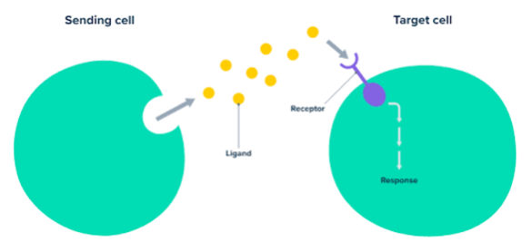

Visão geral da comunicação célula–célula.

## Do cluster ao tecido

1. Inferir comunicações entre clusters.
2. Localizar os spots de origem e destino.
3. Restringir a comunicação a spots espacialmente próximos.
4. Associar a comunicação às arestas da rede.
5. Projetar o sinal com PathwaySpace.

## Inferência das redes de comunicação

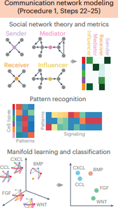

Modelagem das redes, identificação de padrões e classificação dos sinais.

## Probabilidade de comunicação

[figure not shown]

Relações entre ligantes, receptores e cofatores no modelo do CellChat.

## Entrada: expressão e grupos

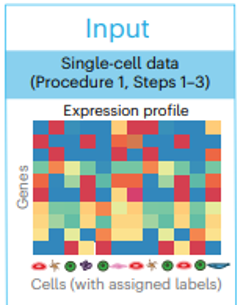

Perfis de expressão e rótulos dos grupos celulares.

## Entrada: interações ligante–receptor

[figure not shown]

Base de ligantes, receptores, agonistas, antagonistas e cofatores.

## Carregar a seção anterior

```r
brain <- readRDS(file.path(diretorio_dados, "brain.RDS"))
brain <- subset(brain, subset = region == "anterior")

DefaultAssay(brain) <- "SCT"
Idents(brain) <- "seurat_clusters"

if (length(Images(brain)) != 1L) {
  stop("O subset da região anterior deve manter exatamente uma imagem espacial.")
}

nome_imagem <- Images(brain)[1]

brain
table(brain$region)
```

O resultado esperado é um objeto com 2.696 spots e uma única imagem, denominada anterior1.

## Expressão e metadados

```r
data.input <- LayerData(brain, assay = "SCT", layer = "data")
spots_anterior <- Cells(brain[[nome_imagem]])
data.input <- data.input[, spots_anterior, drop = FALSE]

metadados_brain <- brain[[]]

meta <- data.frame(
  labels = paste0("cluster_",
    metadados_brain[colnames(data.input), "seurat_clusters"]),
  samples = nome_imagem,
  row.names = colnames(data.input)
)

meta$labels <- factor(meta$labels)
meta$samples <- factor(meta$samples, levels = nome_imagem)

table(meta$labels, meta$samples)
```

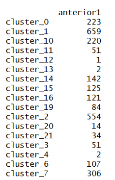

Número de spots por cluster na seção anterior.

## Coordenadas e escala física

```r
spatial.locs <- GetTissueCoordinates(
  brain, image = nome_imagem, scale = NULL)
spatial.locs <- as.data.frame(spatial.locs[, c("x", "y"), drop = FALSE])
spatial.locs <- spatial.locs[colnames(data.input), , drop = FALSE]

spot.size <- 55
distancia_centros <- 100
distancias <- computeCellDistance(coordinates = spatial.locs)
menor_distancia <- min(distancias[distancias > 0])

spatial.factors <- data.frame(
  ratio = distancia_centros / menor_distancia,
  tol = spot.size / 2,
  row.names = nome_imagem
)

spatial.factors
head(spatial.locs)
```

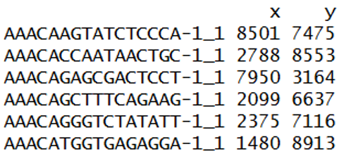

Coordenadas espaciais alinhadas à expressão.

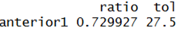

Fator de conversão espacial.

## Criar o objeto CellChat

```r
cellchat <- createCellChat(
  object = data.input, meta = meta, group.by = "labels",
  datatype = "spatial", coordinates = spatial.locs,
  spatial.factors = spatial.factors
)

cellchat
```

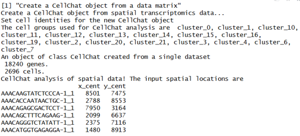

Resumo do objeto CellChat espacial.

## Banco de interações

```r
CellChatDB <- CellChatDB.mouse
showDatabaseCategory(CellChatDB)

CellChatDB.use <- subsetDB(CellChatDB,
  search = "Secreted Signaling", key = "annotation")

cellchat@DB <- CellChatDB.use
```

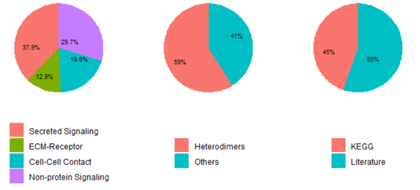

Categorias de interação disponíveis no CellChatDB.mouse.

## Pré-processar e inferir

```r
cellchat <- subsetData(cellchat)

future::plan("multisession", workers = 4)

cellchat <- identifyOverExpressedGenes(cellchat)
cellchat <- identifyOverExpressedInteractions(cellchat, variable.both = FALSE)

cellchat <- computeCommunProb(
  cellchat, type = "triMean", distance.use = TRUE,
  interaction.range = 100, scale.distance = 0.01,
  contact.range = 100, contact.dependent = TRUE,
  contact.knn.k = 6, nboot = 10
)

cellchat <- filterCommunication(cellchat, min.cells = 10)
```

> CUIDADO: Esta é a etapa mais custosa da vinheta. O número de permutações foi limitado a 10 para a atividade didática.

## Comunicações entre clusters

```r
df.net <- subsetCommunication(cellchat, thresh = 0.05)

df.net <- df.net %>%
  mutate(source = as.character(source), target = as.character(target))

head(df.net)
```

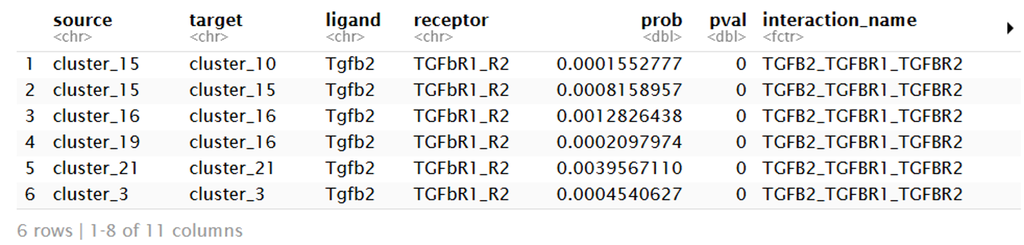

Tabela de interações inferidas entre clusters.

## Pares de spots próximos

```r
interaction.range <- 100

coordenadas_um <- spatial.locs * spatial.factors[nome_imagem, "ratio"]
matriz_distancias <- as.matrix(dist(coordenadas_um))
diag(matriz_distancias) <- Inf

indices <- which(matriz_distancias <= interaction.range, arr.ind = TRUE)

spot.pairs <- tibble(
  source_spot = rownames(matriz_distancias)[indices[, 1]],
  target_spot = colnames(matriz_distancias)[indices[, 2]],
  distance_um = matriz_distancias[indices],
  sample = nome_imagem
)

spot.groups <- tibble(spot = rownames(cellchat@meta),
  group = as.character(cellchat@idents))
```

[figure not shown]

Pares de spots dentro do intervalo espacial.

## Projetar clusters nos pares de spots

```r
spot.pairs <- spot.pairs %>%
  left_join(spot.groups, by = c("source_spot" = "spot")) %>%
  rename(source = group) %>%
  left_join(spot.groups, by = c("target_spot" = "spot")) %>%
  rename(target = group)

head(spot.pairs)
```

Cada par recebe o cluster do spot de origem e o cluster do spot de destino.

## Combinar e salvar as comunicações

```r
spot.to.spot.communication <- spot.pairs %>%
  inner_join(df.net, by = c("source", "target")) %>%
  arrange(sample, source_spot, target_spot,
    pathway_name, interaction_name)

head(spot.to.spot.communication)

saveRDS(
  spot.to.spot.communication,
  file = file.path(diretorio_resultados,
    "spot-spot_commu_anterior.rds")
)
```

[figure not shown]

## Construir o GraphSpace

```r
spots_visualizacao <- spots_anterior

coordenadas_gs <- GetTissueCoordinates(
  brain, image = nome_imagem, scale = "lowres"
)
coordenadas_gs <- coordenadas_gs[
  spots_visualizacao, c("x", "y"), drop = FALSE
]

metadados_gs <- brain[[]][spots_visualizacao, , drop = FALSE]
gs <- GraphSpace(cbind(coordenadas_gs, metadados_gs))

gs_fdata(gs) <- LayerData(
  brain, assay = "SCT", layer = "data"
)[, spots_visualizacao, drop = FALSE]

gs_image(gs) <- GetImage(
  brain[[nome_imagem]], mode = "raster"
)

gs <- normalizeGraphSpace(gs)
```

## Clusters no GraphSpace

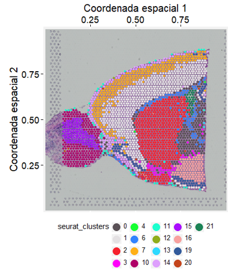

Distribuição espacial dos clusters.

```r
spatial_theme <- theme_gspace_coords(
  theme = "th3", is_norm = TRUE,
  xlab = "Coordenada espacial 1", ylab = "Coordenada espacial 2"
)

cpal1 <- DiscretePalette(nlevels(gs$seurat_clusters), "polychrome")

ggplot(gs) +
  annotation_gspace_image(gs) +
  geom_nodespace(mapping = aes(colour = seurat_clusters),
    size = 1, pch = 19) +
  scale_colour_manual(values = cpal1) +
  theme_gspace_legend(discrete_colour = TRUE) +
  spatial_theme
```

## Rede de proximidade

```r
proximityNetwork <- function(gs, nnei = 6) {
  nodes <- gs@nodes

  vizinhos <- RANN::nn2(nodes[, c("x", "y")],
    nodes[, c("x", "y")], k = nnei + 1)

  distancias <- as.data.frame(vizinhos$nn.dists[, 2:(nnei + 1)])
  indices <- as.data.frame(vizinhos$nn.idx[, 2:(nnei + 1)])

  distancia_tipica <- 1 / mean(1 / distancias$V1)
  manter <- distancias
  manter[, 1] <- TRUE
  manter[, 2:ncol(manter)] <-
    distancias[, 2:ncol(distancias)] >= 0.95 * distancia_tipica &
    distancias[, 2:ncol(distancias)] <= 1.05 * distancia_tipica

  matriz_arestas <- manter * indices
  matriz_arestas$from <- row.names(matriz_arestas)

  arestas <- matriz_arestas %>%
    pivot_longer(cols = -from, names_to = "vizinho", values_to = "to") %>%
    filter(to != 0) %>%
    transmute(from = as.numeric(from), to = as.numeric(to),
      v1 = pmin(from, to), v2 = pmax(from, to)) %>%
    distinct(v1, v2) %>%
    transmute(from = nodes$name[v1], to = nodes$name[v2])

  gs_add_edges(gs) <- arestas
  gs
}
```

## Antes da rede de proximidade

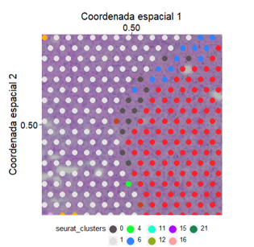

Recorte central antes de acrescentar as arestas.

```r
ggplot(gs) +
  annotation_gspace_image(gs) +
  geom_edgespace() +
  geom_nodespace(mapping = aes(colour = seurat_clusters),
    size = 3, pch = 19) +
  scale_colour_manual(values = cpal1) +
  theme_gspace_legend(discrete_colour = TRUE) +
  spatial_theme +
  coord_cartesian(xlim = c(0.4, 0.6), ylim = c(0.4, 0.6))
```

## Depois da rede de proximidade

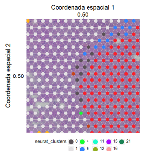

Os seis vizinhos mais próximos definem as arestas compatíveis com a malha Visium.

```r
gs <- proximityNetwork(gs)

ggplot(gs) +
  annotation_gspace_image(gs) +
  geom_edgespace() +
  geom_nodespace(mapping = aes(colour = seurat_clusters),
    size = 3, pch = 19) +
  scale_colour_manual(values = cpal1) +
  theme_gspace_legend(discrete_colour = TRUE) +
  spatial_theme +
  coord_cartesian(xlim = c(0.4, 0.6), ylim = c(0.4, 0.6))
```